# Name: Haonan Li

Student number: 21124200

0:00:09, 18 十二月, 2021

**Originality declaration**

I, [**Haonan Li**], confirm that the work presented in this assessment is my own. Where information has been derived from other sources, I confirm that this has been indicated in the work.

date: 18 十二月, 2021

# 1 Backgrounds and Objectives

The relationship between obesity and diet is very close. London region faces a very serious threat of obesity. It is great significance to study the distribution of obesity and diet in different London regions to suggest some sensible dietary changes. Therfore, We will first visualiseobesity and dietin different London regions to better understand the relationship between obesity and diet in the city.

# 2 Data and libraries

## 2.1 Load libraries

```r
suppressWarnings(suppressMessages(library(sf)))
suppressWarnings(suppressMessages(library(tmap)))
suppressWarnings(suppressMessages(library(tidyverse)))
suppressWarnings(suppressMessages(library(spatstat)))
suppressWarnings(suppressMessages(library(maptools)))
suppressWarnings(suppressMessages(library(nngeo)))
suppressWarnings(suppressMessages(library(data.table)))
suppressWarnings(suppressMessages(library(spdep)))
suppressWarnings(suppressMessages(library(sp)))
suppressWarnings(suppressMessages(library(rgdal)))
suppressWarnings(suppressMessages(library(rgeos)))


# change work path
# set the working directory path to the folder you wish to use
setwd('./')
```

## 2.2 Load data

To explore the relationships of obesity and diet , we use three datasets, including grocery of nutrients information, msoa_data of obesity information, and the MSOA of geographic information. #Firstly, I download the the obesity and diet in London from London Datastore (https://figshare.com/articles/dataset/Area-level_grocery_purchases/7796666?backTo=/collections/Tesco_Grocery_1_0/4769354).

```r
# load data

MSOA <- st_read('statistical-gis-boundaries-london\\ESRI\\MSOA_2011_London_gen_MHW.shp')
grocery <- read_csv('year_msoa_grocery.csv')
msoa_data<- read_csv('msoa_data.csv')

# inspect
head(MSOA)
```

```
## Simple feature collection with 6 features and 12 fields
## Geometry type: MULTIPOLYGON
## Dimension:     XY
## Bounding box:  xmin: 530966.7 ymin: 180510.7 xmax: 551943.8 ymax: 191139
## Projected CRS: OSGB 1936 / British National Grid
##    MSOA11CD                 MSOA11NM   LAD11CD              LAD11NM   RGN11CD
## 1 E02000001       City of London 001 E09000001       City of London E12000007
## 2 E02000002 Barking and Dagenham 001 E09000002 Barking and Dagenham E12000007
## 3 E02000003 Barking and Dagenham 002 E09000002 Barking and Dagenham E12000007
## 4 E02000004 Barking and Dagenham 003 E09000002 Barking and Dagenham E12000007
## 5 E02000005 Barking and Dagenham 004 E09000002 Barking and Dagenham E12000007
## 6 E02000007 Barking and Dagenham 006 E09000002 Barking and Dagenham E12000007
##   RGN11NM USUALRES HHOLDRES COMESTRES POPDEN HHOLDS AVHHOLDSZ
## 1  London     7375     7187       188   25.5   4385       1.6
## 2  London     6775     6724        51   31.3   2713       2.5
## 3  London    10045    10033        12   46.9   3834       2.6
## 4  London     6182     5937       245   24.8   2318       2.6
## 5  London     8562     8562         0   72.1   3183       2.7
## 6  London     8791     8672       119   50.6   3441       2.5
##                         geometry
## 1 MULTIPOLYGON (((531667.6 18...
## 2 MULTIPOLYGON (((548881.6 19...
## 3 MULTIPOLYGON (((549102.4 18...
## 4 MULTIPOLYGON (((551550 1873...
## 5 MULTIPOLYGON (((549099.6 18...
## 6 MULTIPOLYGON (((549819.9 18...
```

```r
head(grocery)
```

```
## # A tibble: 6 x 202
##   area_id   weight weight_perc2.5 weight_perc25 weight_perc50 weight_perc75
##   <chr>      <dbl>          <dbl>         <dbl>         <dbl>         <dbl>
## 1 E02000001   323.           35             150           250           400
## 2 E02000002   398.           32.5           150           300           500
## 3 E02000003   371.           30             140           250           450
## 4 E02000004   347.           29             126           250           430
## 5 E02000005   401.           32.5           150           296           500
## 6 E02000007   388.           32.5           150           300           486
## # ... with 196 more variables: weight_perc97.5 <dbl>, weight_std <dbl>,
## #   weight_ci95 <dbl>, volume <dbl>, volume_perc2.5 <dbl>, volume_perc25 <dbl>,
## #   volume_perc50 <dbl>, volume_perc75 <dbl>, volume_perc97.5 <dbl>,
## #   volume_std <dbl>, volume_ci95 <dbl>, fat <dbl>, fat_perc2.5 <dbl>,
## #   fat_perc25 <dbl>, fat_perc50 <dbl>, fat_perc75 <dbl>, fat_perc97.5 <dbl>,
## #   fat_std <dbl>, fat_ci95 <dbl>, saturate <dbl>, saturate_perc2.5 <dbl>,
## #   saturate_perc25 <dbl>, saturate_perc50 <dbl>, saturate_perc75 <dbl>,
## #   saturate_perc97.5 <dbl>, saturate_std <dbl>, saturate_ci95 <dbl>,
## #   salt <dbl>, salt_perc2.5 <dbl>, salt_perc25 <dbl>, salt_perc50 <dbl>,
## #   salt_perc75 <dbl>, salt_perc97.5 <dbl>, salt_std <dbl>, salt_ci95 <dbl>,
## #   sugar <dbl>, sugar_perc2.5 <dbl>, sugar_perc25 <dbl>, sugar_perc50 <dbl>,
## #   sugar_perc75 <dbl>, sugar_perc97.5 <dbl>, sugar_std <dbl>,
## #   sugar_ci95 <dbl>, protein <dbl>, protein_perc2.5 <dbl>,
## #   protein_perc25 <dbl>, protein_perc50 <dbl>, protein_perc75 <dbl>,
## #   protein_perc97.5 <dbl>, protein_std <dbl>, protein_ci95 <dbl>, carb <dbl>,
## #   carb_perc2.5 <dbl>, carb_perc25 <dbl>, carb_perc50 <dbl>,
## #   carb_perc75 <dbl>, carb_perc97.5 <dbl>, carb_std <dbl>, carb_ci95 <dbl>,
## #   fibre <dbl>, fibre_perc2.5 <dbl>, fibre_perc25 <dbl>, fibre_perc50 <dbl>,
## #   fibre_perc75 <dbl>, fibre_perc97.5 <dbl>, fibre_std <dbl>,
## #   fibre_ci95 <dbl>, alcohol <dbl>, alcohol_perc2.5 <dbl>,
## #   alcohol_perc25 <dbl>, alcohol_perc50 <dbl>, alcohol_perc75 <dbl>,
## #   alcohol_perc97.5 <dbl>, alcohol_std <dbl>, alcohol_ci95 <dbl>,
## #   energy_fat <dbl>, energy_fat_perc2.5 <dbl>, energy_fat_perc25 <dbl>,
## #   energy_fat_perc50 <dbl>, energy_fat_perc75 <dbl>,
## #   energy_fat_perc97.5 <dbl>, energy_fat_std <dbl>, energy_fat_ci95 <dbl>,
## #   energy_saturate <dbl>, energy_saturate_perc2.5 <dbl>,
## #   energy_saturate_perc25 <dbl>, energy_saturate_perc50 <dbl>,
## #   energy_saturate_perc75 <dbl>, energy_saturate_perc97.5 <dbl>,
## #   energy_saturate_std <dbl>, energy_saturate_ci95 <dbl>, energy_sugar <dbl>,
## #   energy_sugar_perc2.5 <dbl>, energy_sugar_perc25 <dbl>,
## #   energy_sugar_perc50 <dbl>, energy_sugar_perc75 <dbl>,
## #   energy_sugar_perc97.5 <dbl>, energy_sugar_std <dbl>,
## #   energy_sugar_ci95 <dbl>, energy_protein <dbl>, ...
```

```r
head(msoa_data)
```

```
## # A tibble: 6 x 207
##   `Middle Super Outp~ `MSOA Name`     `Age Structure (2011~ `Age Structure (201~
##   <chr>               <chr>                           <dbl>                <dbl>
## 1 E02000001           City of London~                  7375                  620
## 2 E02000002           Barking and Da~                  6775                 1751
## 3 E02000003           Barking and Da~                 10045                 2247
## 4 E02000004           Barking and Da~                  6182                 1196
## 5 E02000005           Barking and Da~                  8562                 2200
## 6 E02000007           Barking and Da~                  8791                 2388
## # ... with 203 more variables: Age Structure (2011 Census);16-29; <dbl>,
## #   Age Structure (2011 Census);30-44; <dbl>,
## #   Age Structure (2011 Census);45-64; <dbl>,
## #   Age Structure (2011 Census);65+; <dbl>,
## #   Age Structure (2011 Census);Working-age; <dbl>,
## #   Mid-year Estimate totals;All Ages;2002 <dbl>,
## #   Mid-year Estimate totals;All Ages;2003 <dbl>,
## #   Mid-year Estimate totals;All Ages;2004 <dbl>,
## #   Mid-year Estimate totals;All Ages;2005 <dbl>,
## #   Mid-year Estimate totals;All Ages;2006 <dbl>,
## #   Mid-year Estimate totals;All Ages;2007 <dbl>,
## #   Mid-year Estimate totals;All Ages;2008 <dbl>,
## #   Mid-year Estimate totals;All Ages;2009 <dbl>,
## #   Mid-year Estimate totals;All Ages;2010 <dbl>,
## #   Mid-year Estimate totals;All Ages;2011 <dbl>,
## #   Mid-year Estimate totals;All Ages;2012 <dbl>,
## #   Mid-year Estimates 2012, by age;% 0 to 14; <dbl>,
## #   Mid-year Estimates 2012, by age;% 15-64; <dbl>,
## #   Mid-year Estimates 2012, by age;% 65+; <dbl>,
## #   Mid-year Estimates 2012, by age;0-4; <dbl>,
## #   Mid-year Estimates 2012, by age;5-9; <dbl>,
## #   Mid-year Estimates 2012, by age;10-14; <dbl>,
## #   Mid-year Estimates 2012, by age;15-19; <dbl>,
## #   Mid-year Estimates 2012, by age;20-24; <dbl>,
## #   Mid-year Estimates 2012, by age;25-29; <dbl>,
## #   Mid-year Estimates 2012, by age;30-34; <dbl>,
## #   Mid-year Estimates 2012, by age;35-39; <dbl>,
## #   Mid-year Estimates 2012, by age;40-44; <dbl>,
## #   Mid-year Estimates 2012, by age;45-49; <dbl>,
## #   Mid-year Estimates 2012, by age;50-54; <dbl>,
## #   Mid-year Estimates 2012, by age;55-59; <dbl>,
```

[output cut: 47 more lines]

```
## #   Religion (2011);No religion (%); <dbl>,
## #   Religion (2011);Religion not stated (%); <dbl>,
## #   Tenure (2011);Owned: Owned outright; <dbl>,
## #   Tenure (2011);Owned: Owned with a mortgage or loan; <dbl>,
## #   Tenure (2011);Social rented; <dbl>, Tenure (2011);Private rented; <dbl>,
## #   Tenure (2011);Owned: Owned outright (%); <dbl>,
## #   Tenure (2011);Owned: Owned with a mortgage or loan (%); <dbl>,
## #   Tenure (2011);Social rented (%); <dbl>,
## #   Tenure (2011);Private rented (%); <dbl>,
## #   Dwelling type (2011);Household spaces with at least one usual resident; <dbl>,
## #   Dwelling type (2011);Household spaces with no usual residents; <dbl>,
## #   Dwelling type (2011);Whole house or bungalow: Detached; <dbl>,
## #   Dwelling type (2011);Whole house or bungalow: Semi-detached; <dbl>,
## #   Dwelling type (2011);Whole house or bungalow: Terraced (including end-terrace); <dbl>,
## #   ...
```

## 2.3 Tidy data

tidy for grocery, we just remain nutrient variables.

```r
remains <-c("area_id","weight","volume","fat","saturate","salt","sugar","protein","carb",
            "fibre","alcohol","population","male","female")
obesity_diet2 <-grocery[,remains]
#nutrients
obesity_diet3<- obesity_diet2 %>%
                  pivot_longer(
                  cols = c(fat, saturate, salt, sugar, protein, carb,fibre),
                  names_to = "nutrients",
                  values_to = "count"
                )
colnames(obesity_diet3)[ncol(obesity_diet3)] <-'nutrients_gram'

#msoa_data
msoa_data2 <- msoa_data[,c(1,176)]
colnames(msoa_data2) <-c("area_id","obesity_ratio")
```

## 2.4 Merge data

merge nutrients and obesity by area_id

```r
msoa_nutrients <-merge(obesity_diet3,msoa_data2, by='area_id')
head(msoa_nutrients)
```

```
##     area_id   weight   volume   alcohol population male female nutrients
## 1 E02000001 323.1808 98.84923 0.3407333       6687 3697   2990       fat
## 2 E02000001 323.1808 98.84923 0.3407333       6687 3697   2990  saturate
## 3 E02000001 323.1808 98.84923 0.3407333       6687 3697   2990      salt
## 4 E02000001 323.1808 98.84923 0.3407333       6687 3697   2990     sugar
## 5 E02000001 323.1808 98.84923 0.3407333       6687 3697   2990   protein
## 6 E02000001 323.1808 98.84923 0.3407333       6687 3697   2990      carb
##   nutrients_gram obesity_ratio
## 1      8.4737464          13.7
## 2      3.3618727          13.7
## 3      0.5304672          13.7
## 4      9.2783851          13.7
## 5      5.2530991          13.7
## 6     15.7793110          13.7
```

```r
# join msoa_nutrients with MSOA of geographic information
MSOA_obesity_diet <- merge(MSOA, msoa_nutrients, by.x='MSOA11CD', by.y='area_id')

# inspect
MSOA_obesity_diet
```

```
## Simple feature collection with 6881 features and 21 fields
## Geometry type: MULTIPOLYGON
## Dimension:     XY
## Bounding box:  xmin: 503574.2 ymin: 155850.8 xmax: 561956.7 ymax: 200933.6
## Projected CRS: OSGB 1936 / British National Grid
## First 10 features:
##     MSOA11CD                 MSOA11NM   LAD11CD              LAD11NM   RGN11CD
## 1  E02000001       City of London 001 E09000001       City of London E12000007
## 2  E02000001       City of London 001 E09000001       City of London E12000007
## 3  E02000001       City of London 001 E09000001       City of London E12000007
## 4  E02000001       City of London 001 E09000001       City of London E12000007
## 5  E02000001       City of London 001 E09000001       City of London E12000007
## 6  E02000001       City of London 001 E09000001       City of London E12000007
## 7  E02000001       City of London 001 E09000001       City of London E12000007
## 8  E02000002 Barking and Dagenham 001 E09000002 Barking and Dagenham E12000007
```

[output cut: 35 more lines]

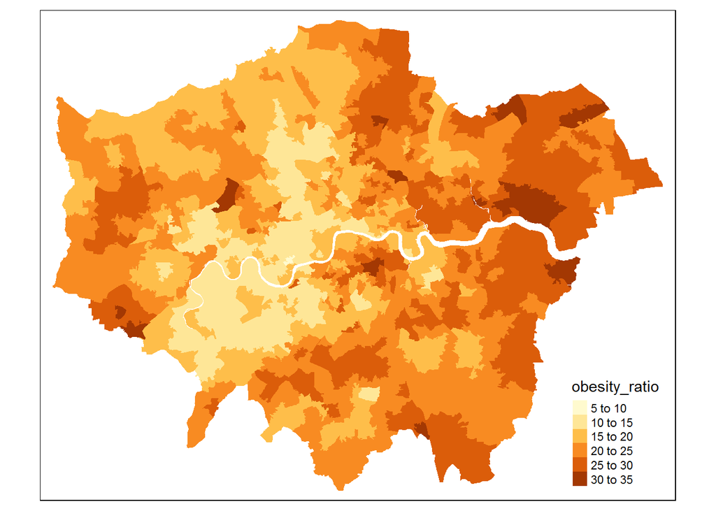

```r
# inspect
tm_shape(MSOA_obesity_diet) + tm_fill(col='obesity_ratio')
```

**NOTE:** From the distribution of obesity_ratio, we can find that distict region shows different ratio of obseity ratio. However, we donot known whether it is clusters of region of obseity.

# 3 Data Analysis

## 3.1 Spatial autocorrelation

Spatial dependence between different London ward is very important for observations of obseity distribution. Spatial autocorrelation occurs when these wards are not independent of one another and instead cluster together across geographic space. In other words, it quantifies the degree of which objects are similar to nearby objects. Variables are said to have a positive spatial autocorrelation when similar values tend to be closer together than dissimilar values. Waldo Tober’s first law of geography is that “Everything is related to everything else, but near things are more related than distant things.” so we would expect most geographic phenomena to exert a spatial autocorrelation of some kind. Here we firstly performed Global Moran’s I method to measure how “random” the spatial distribution of these values is. And secondly, Local Moran’s Imethod is also used.

```r
# convert to sp
MSOA_obesity_diet_sp <- as_Spatial(MSOA_obesity_diet, IDs=MSOA_obesity_diet$area_id)
# inspect
class(MSOA_obesity_diet_sp)
```

```
## [1] "SpatialPolygonsDataFrame"
## attr(,"package")
## [1] "sp"
```

### 3.1.1 Global Moran’s I

```
We can represent spatial autocorrelation in two ways; globally or locally. Global models will create a single measure to represent the entire study area, whilst local models let us explore how spatial clustering varies across space.
Global Moran’s I is a metric between -1 and 1. -1 is a completely even spatial distribution of values, 0 is a “random” distribution, and 1 is a “non-random” distribution of clearly defined clusters.
```

```r
library(spdep)

# Calculate neighbours, create an nb object
MSOA_obesity_diet_sp_nb <- poly2nb(MSOA_obesity_diet_sp, row.names=MSOA_obesity_diet_sp$area_id)

# inspect
class(MSOA_obesity_diet_sp_nb)
```

```
## [1] "nb"
```

```r
# inspect
str(MSOA_obesity_diet_sp_nb,list.len=10)
```

```
## List of 6881
##  $ : int [1:6] 2 3 4 5 6 7
##  $ : int [1:6] 1 3 4 5 6 7
##  $ : int [1:6] 1 2 4 5 6 7
##  $ : int [1:6] 1 2 3 5 6 7
##  $ : int [1:6] 1 2 3 4 6 7
##  $ : int [1:6] 1 2 3 4 5 7
##  $ : int [1:6] 1 2 3 4 5 6
##  $ : int [1:6] 9 10 11 12 13 14
##  $ : int [1:6] 8 10 11 12 13 14
##  $ : int [1:6] 8 9 11 12 13 14
##   [list output truncated]
##  - attr(*, "class")= chr "nb"
##  - attr(*, "region.id")= chr [1:6881] "1" "2" "3" "4" ...
##  - attr(*, "call")= language poly2nb(pl = MSOA_obesity_diet_sp, row.names = MSOA_obesity_diet_sp$area_id)
##  - attr(*, "type")= chr "queen"
##  - attr(*, "sym")= logi TRUE
```

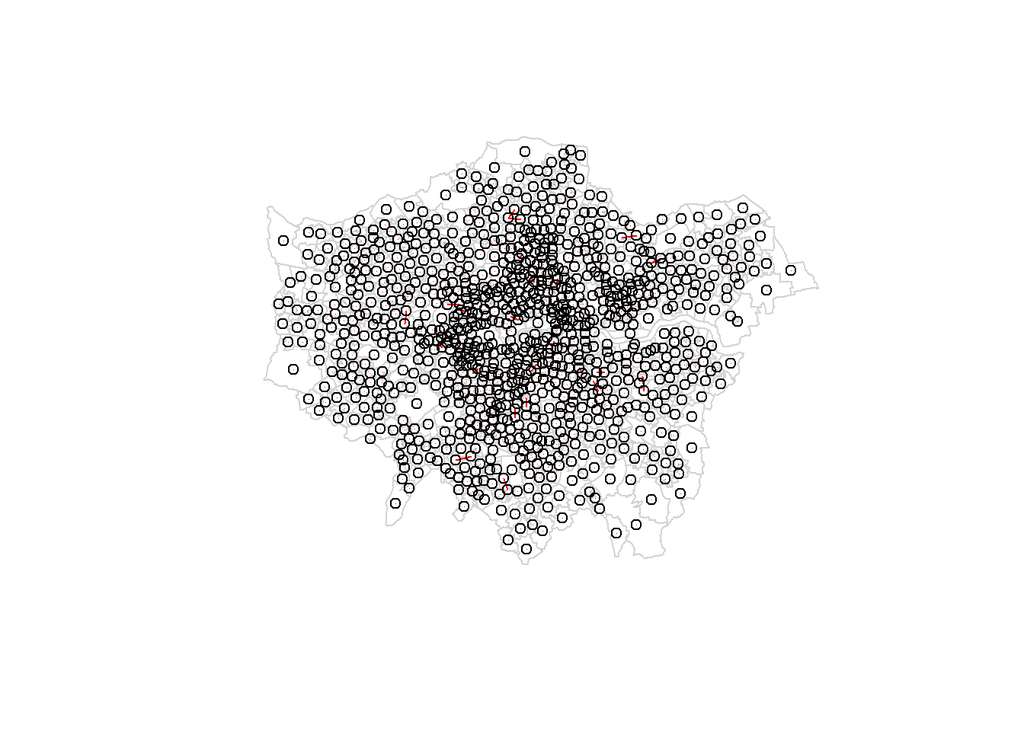

```r
#We can plot the links between neighbours to visualise their distribution across space.
plot(MSOA_obesity_diet_sp, border = 'lightgrey')
plot(MSOA_obesity_diet_sp_nb, coordinates(MSOA_obesity_diet_sp), add=TRUE, col='red')
```

```r
#We can already see that this approach has identified fewer links between neighbours. By plotting both neighbour outputs we can interpret their differences.

# create the list weights object
nb_weights_list <- nb2listw(MSOA_obesity_diet_sp_nb, style='W')

# inspect
nb_weights_list
```

```
## Characteristics of weights list object:
## Neighbour list object:
## Number of regions: 6881
## Number of nonzero links: 43736
## Percentage nonzero weights: 0.09237106
## Average number of links: 6.356053
##
## Weights style: W
## Weights constants summary:
##      n       nn   S0       S1       S2
## W 6881 47348161 6881 2231.655 27525.49
```

Inference for Moran’s I is based on a null hypothesis of spatial randomness. The distribution of the statistic under the null can be derived using either an assumption of normality (independent normal random variates), or so-called randomization (i.e., each value is equally likely to occur at any location).

```r
# Moran's I
mi_value <- moran(MSOA_obesity_diet_sp$obesity_ratio,nb_weights_list,n=length(nb_weights_list$neighbours),S0=Szero(nb_weights_list))

# inspect
mi_value
```

```
## $I
## [1] 0.9953213
##
## $K
## [1] 2.043046
```

```r
# global spatial autocorrelation
moran.test(MSOA_obesity_diet_sp$obesity_ratio,nb_weights_list)
```

```
##
##  Moran I test under randomisation
##
## data:  MSOA_obesity_diet_sp$obesity_ratio
## weights: nb_weights_list
##
## Moran I statistic standard deviate = 145.05, p-value < 2.2e-16
## alternative hypothesis: greater
## sample estimates:
## Moran I statistic       Expectation          Variance
##      9.953213e-01     -1.453488e-04      4.709717e-05
```

**NOTE:** The moran I statistic is 0.995, we can therefore determine that there obesity_ratio variable is positively autocorrelated in London. In other words, the data does spatially cluster. We can also consider the p-value to consider the statistical significance of the mode.

Furthermore, we can do this by using something called a Monte Carlo simulation.

```r
# run a Monte Carlo simulation 599 times
mc_model <- moran.mc(MSOA_obesity_diet_sp$obesity_ratio, nb_weights_list, nsim=599)
mc_model
```

```
##
##  Monte-Carlo simulation of Moran I
##
## data:  MSOA_obesity_diet_sp$obesity_ratio
## weights: nb_weights_list
## number of simulations + 1: 600
##
## statistic = 0.99532, observed rank = 600, p-value = 0.001667
## alternative hypothesis: greater
```

**NOTE:** This model shows that our distribution of obesity_ratio do differs significantly from a random distribution. As such, we can conclude that there is existing global spatial autocorrelation in our data set.

### 3.1.2 Local Moran’s I

```
We will first create a moran plot which looks at each of the values plotted against their spatially lagged values. It basically explores the relationship between the data and their neighbours as a scatter plot.
```

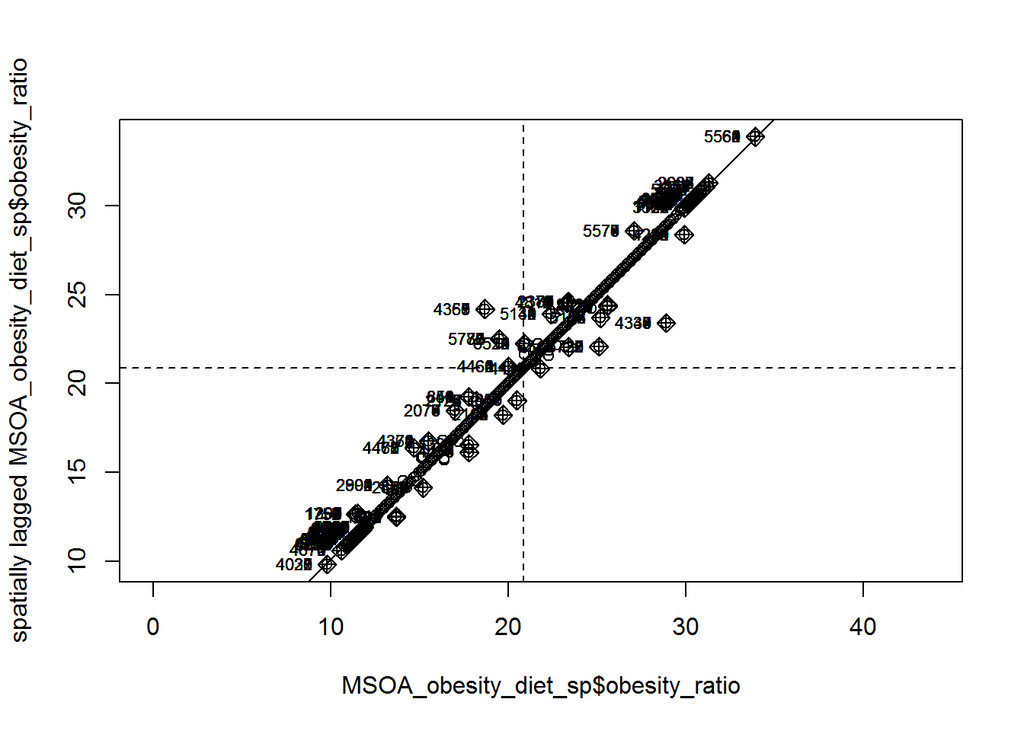

```r
# creates a moran plot
moran <- moran.plot(MSOA_obesity_diet_sp$obesity_ratio, listw = nb2listw(MSOA_obesity_diet_sp_nb, style = "W"),asp=T)
```

```r
#Is it possible to determine a positive relationship from observing the scatter plot.
```

With a measurement of local spatial autocorrelation we could find hotspots of new case identified that are surrounded by areas of much lower case. According to the previous global statistic these are not randomly distributed pockets but would be outliers against the general trend of clusteredness! These could be areas that contain very specific locations, where interventions could be made that drastically reduce the rate of crime rather than other areas where there is a high level of obesity.

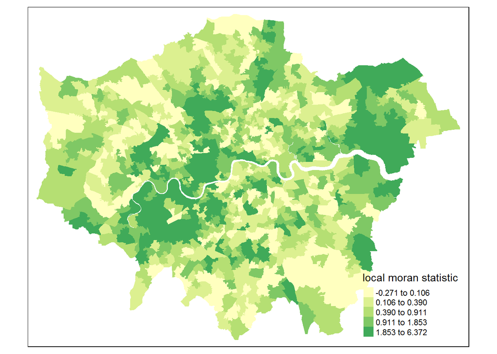

```r
# create an nb object

MSOA_obesity_diet_sp_nb <- poly2nb(MSOA_obesity_diet_sp, row.names=MSOA_obesity_diet_sp$area_id)

# create the list weights object
nb_weights_list <- nb2listw(MSOA_obesity_diet_sp_nb, style='W')

# Local Moran's I
local_moran_MSOA_obesity_diet <- localmoran(MSOA_obesity_diet_sp$obesity_ratio, nb_weights_list)


#First we will map the local moran statistic (Ii). A positive value for Ii indicates that the unit is surrounded by units with similar values.
# binds results to our polygon shapefile
moran.map <- MSOA_obesity_diet_sp
moran.map@data<- cbind(MSOA_obesity_diet_sp@data, local_moran_MSOA_obesity_diet)
# maps the results
tm_shape(moran.map) + tm_fill("Ii", style = "quantile", title = "local moran statistic")
```

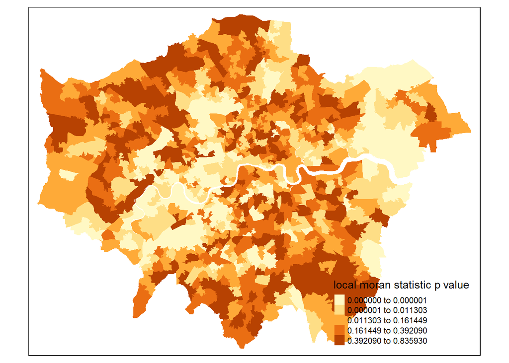

```r
#From the map it is possible to see the variations in autocorrelation across space. We can interpret that there seems to be a geographic pattern to the autocorrelation.
tm_shape(moran.map) + tm_fill("Pr(z > 0)", style = "quantile", title = "local moran statistic p value")
```

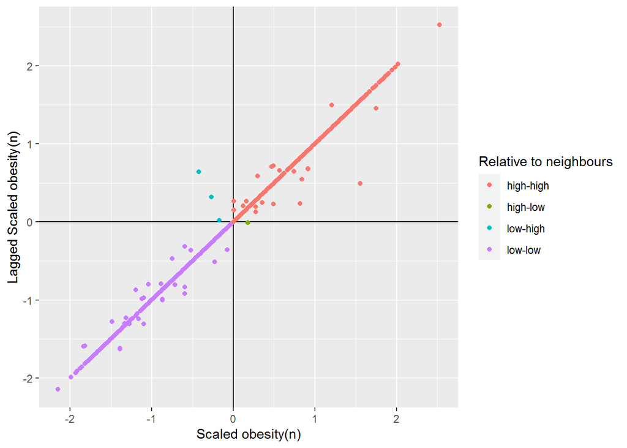

```r
#From the local moran statistic p value, it is possible to see P-value to observe variances in significance across London.


# rescale
MSOA_obesity_diet_sp$scale_obesity_ratio <- scale(MSOA_obesity_diet_sp$obesity_ratio)

# create a spatial lag variable
MSOA_obesity_diet_sp$lag_scale_obesity_ratio <- lag.listw(nb_weights_list, MSOA_obesity_diet_sp$scale_obesity_ratio)

# convert to sf
MSOA_obesity_diet_sp_stats <- st_as_sf(MSOA_obesity_diet_sp)


## calculates what the value of each polygon is compared to its neighbours and works out if they are similar or dissimilar and in which way, then gives them a text label to describe the relationship.
# set a significance value
sig_level <- 0.1
# classification with significance value
MSOA_obesity_diet_sp_stats$quad_sig <- ifelse(MSOA_obesity_diet_sp_stats$scale_obesity_ratio > 0 &
                                          MSOA_obesity_diet_sp_stats$lag_scale_obesity_ratio > 0 &
                                          local_moran_MSOA_obesity_diet[,5] <= sig_level,
                                          'high-high',
                                   ifelse(MSOA_obesity_diet_sp_stats$scale_obesity_ratio <= 0 &
                                          MSOA_obesity_diet_sp_stats$lag_scale_obesity_ratio <= 0 &
                                          local_moran_MSOA_obesity_diet[,5] <= sig_level,
                                          'low-low',
                                   ifelse(MSOA_obesity_diet_sp_stats$scale_obesity_ratio > 0 &
                                          MSOA_obesity_diet_sp_stats$lag_scale_obesity_ratio <= 0 &
                                          local_moran_MSOA_obesity_diet[,5] <= sig_level,
                                          'high-low',
                                   ifelse(MSOA_obesity_diet_sp_stats$scale_obesity_ratio <= 0 &
                                          MSOA_obesity_diet_sp_stats$lag_scale_obesity_ratio > 0 &
                                          local_moran_MSOA_obesity_diet[,5] <= sig_level,
                                          'low-high',
                                   ifelse(local_moran_MSOA_obesity_diet[,5] > sig_level,
                                          'not-significant',
                                          'not-significant')))))

# classification without significance value
MSOA_obesity_diet_sp_stats$quad_non_sig <- ifelse(MSOA_obesity_diet_sp_stats$scale_obesity_ratio > 0 &
                                              MSOA_obesity_diet_sp_stats$lag_scale_obesity_ratio > 0,
'high-high',
                                       ifelse(MSOA_obesity_diet_sp_stats$scale_obesity_ratio <= 0 &
                                              MSOA_obesity_diet_sp_stats$lag_scale_obesity_ratio <= 0,
                                              'low-low',
                                       ifelse(MSOA_obesity_diet_sp_stats$scale_obesity_ratio > 0 &
                                              MSOA_obesity_diet_sp_stats$lag_scale_obesity_ratio <= 0,
                                              'high-low',
                                       ifelse(MSOA_obesity_diet_sp_stats$scale_obesity_ratio <= 0 &
                                              MSOA_obesity_diet_sp_stats$lag_scale_obesity_ratio > 0,
                                              'low-high',NA))))

# plot the results without the statistical significance
ggplot(MSOA_obesity_diet_sp_stats, aes(x = scale_obesity_ratio,
                                   y = lag_scale_obesity_ratio,
                                   color = quad_non_sig)) +
  geom_vline(xintercept = 0) + # plot vertical line
  geom_hline(yintercept = 0) + # plot horizontal line
  xlab('Scaled obesity(n)') +
  ylab('Lagged Scaled obesity(n)') +
  labs(colour='Relative to neighbours') +
  geom_point()
```

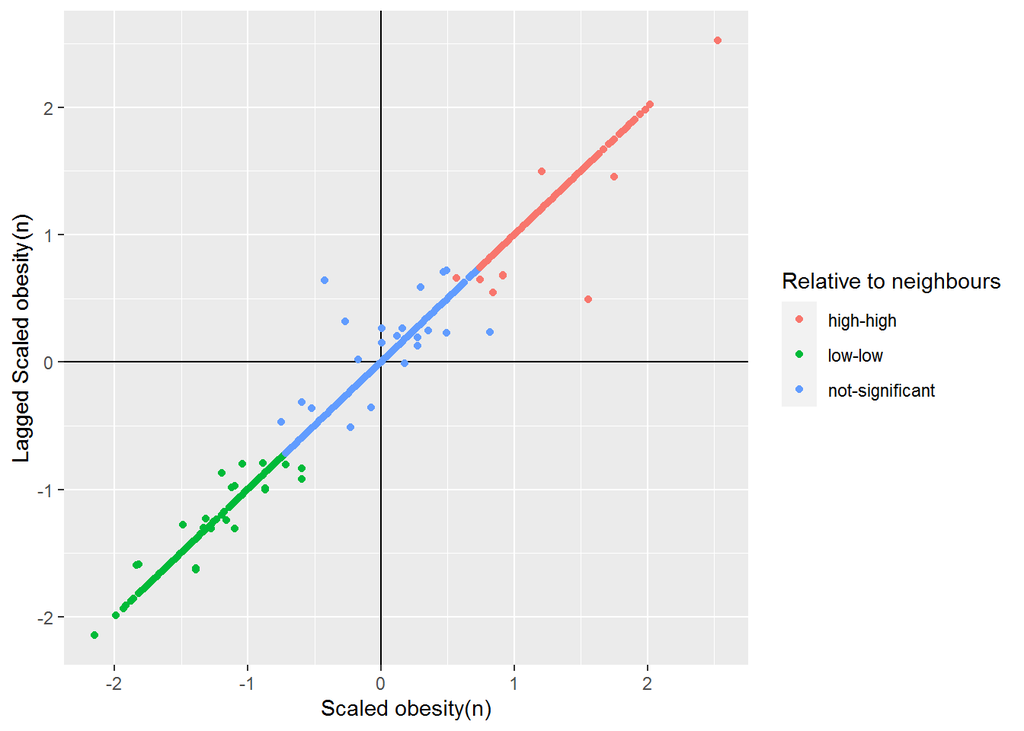

```r
# plot the results with the statistical significance
ggplot(MSOA_obesity_diet_sp_stats, aes(x = scale_obesity_ratio,
                                   y = lag_scale_obesity_ratio,
                                   color = quad_sig)) +
  geom_vline(xintercept = 0) + # plot vertical line
  geom_hline(yintercept = 0) + # plot horizontal line
  xlab('Scaled obesity(n)') +
  ylab('Lagged Scaled obesity(n)') +
  labs(colour='Relative to neighbours') +
  geom_point()
```

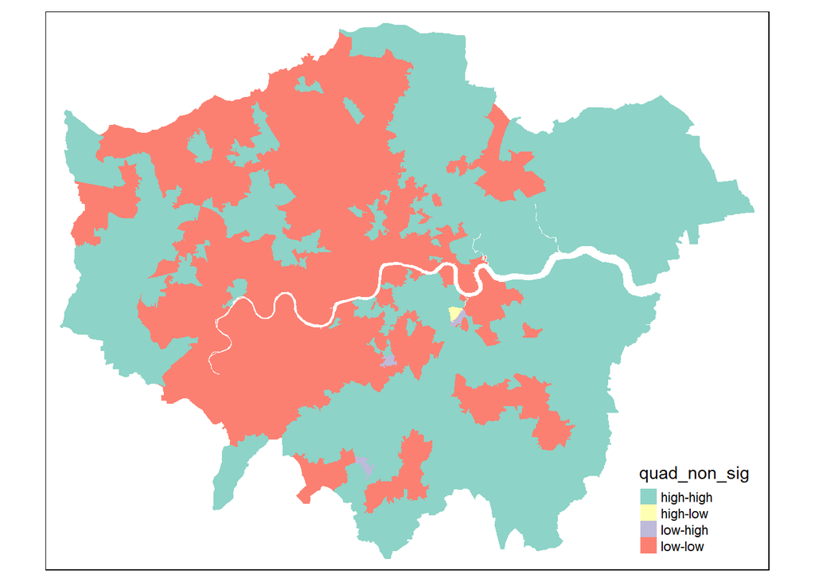

```r
#Now let’s see how they are arranged spatially.
# map all of the results here
tm_shape(MSOA_obesity_diet_sp_stats) +
  tm_fill(col='quad_non_sig')
```

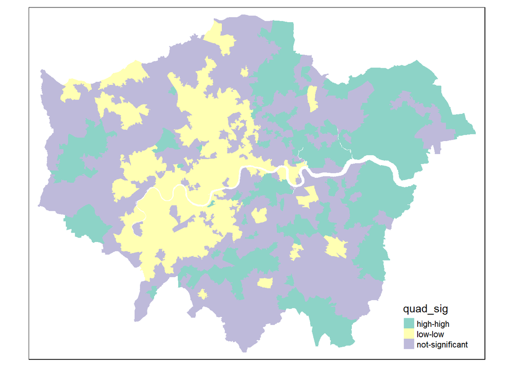

```r
# map only the statistically significant results here
tm_shape(MSOA_obesity_diet_sp_stats) +
  tm_fill(col='quad_sig')
```

**NOTE:** The resulting map reveals that it is apparent that there is a statistically significant geographic pattern to the clustering of obesity variable in London.

## 3.2 Point pattern analysis

```r
#An object of the class ppp represents a two-dimensional point data set within a pre-defined area
# transform sf to sp
MSOA_sp <- as(MSOA,'Spatial')

# get the window of observation using maptools package
window <- as.owin.SpatialPolygons(MSOA_sp)

# inspect
window
```

```
## window: polygonal boundary
## enclosing rectangle: [503574.2, 561956.7] x [155850.8, 200933.61] units
```

```r
# get coordinates from sf object
obesity_diet_points_coords <- matrix(unlist(MSOA_obesity_diet$geometry),ncol=2,byrow=T)

# inspect
head(obesity_diet_points_coords)
```

```
##          [,1]     [,2]
## [1,] 531667.6 531647.2
## [2,] 531626.7 531667.6
## [3,] 180535.0 180532.9
## [4,] 180539.0 180535.0
## [5,] 532135.1 532158.2
## [6,] 532252.9 532293.1
```

```r
# create ppp object
obesity_diet_ppp <- ppp(x=obesity_diet_points_coords[,1],y=obesity_diet_points_coords[,2],window=window,check=T)

# check for duplicates
any(duplicated(obesity_diet_ppp))
```

```
## [1] TRUE
```

```r
# count the number of duplicated points
sum(multiplicity(obesity_diet_ppp) > 1)
```

```
## [1] 3619
```

```r
# add some jitter to our points
obesity_diet_ppp_jitter <- rjitter(obesity_diet_ppp,retry=TRUE,nsim=1,drop=TRUE)

# count the number of duplicated points
any(duplicated(obesity_diet_ppp_jitter))
```

```
## [1] FALSE
```

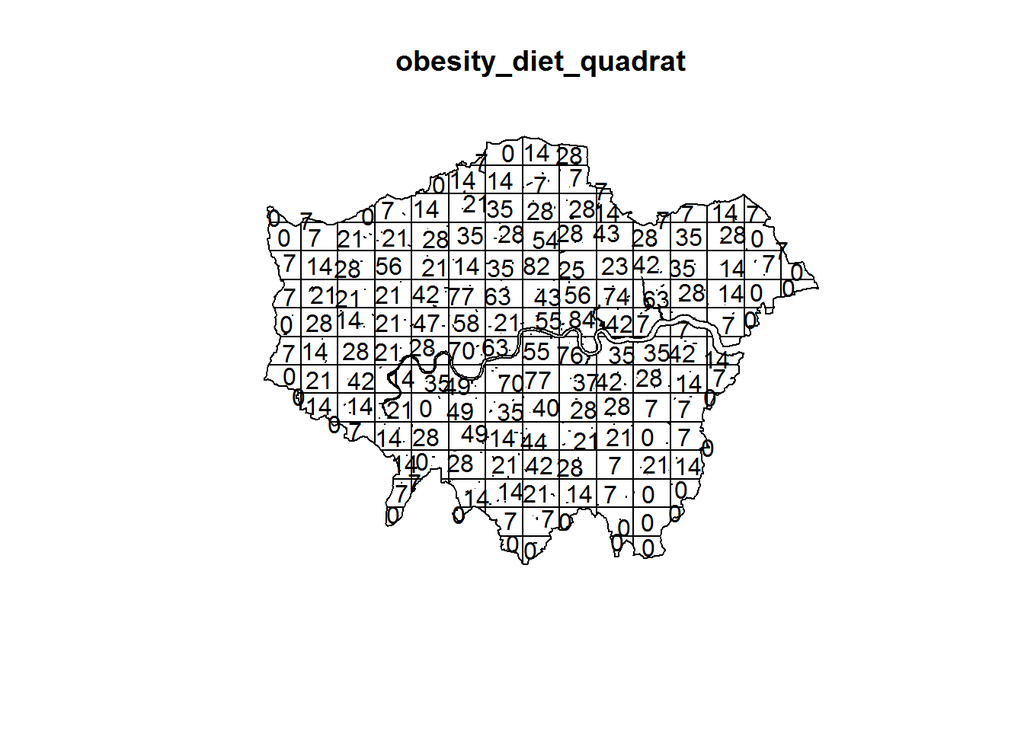

```r
# quadratcount in a 15 x 15 grid across the observational window
obesity_diet_quadrat <- quadratcount(obesity_diet_ppp_jitter,nx=15,ny=15)

# inspect
plot(obesity_diet_quadrat)
```

As we want to know whether or not there is any kind of spatial pattern present in our data, we need to look at our data and ask again whether the pattern is generated in a random manner; i.e. whether the distribution of points in our study area differs from complete spatial randomness (CSR) or whether there are some clusters present. We can do test some quadrats have higher counts than others by using a Poisson point process.

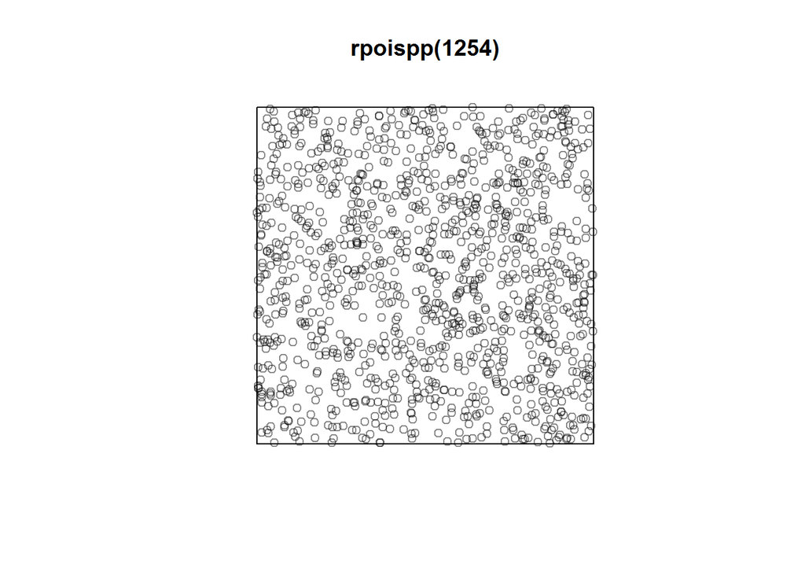

```r
# create and plot a completely spatially random point pattern of the same size as our data
plot(rpoispp(1254))
```

The first thing you will see is that the points are not uniformly distributed. Furthermore, every time you run the function the outcome will be slightly different than the previous time because the points are sampled from a Poisson distribution. To check whether new cocid-19 case points differ from complete spatial randomness (i.e. there is no clustering or dispersal of points) we can run a [Chi-Squared test] with the null hypotheses that our point data have been generated under complete spatial randomness.

```r
# chi-square between observed pattern and Poisson sampled points
quadrat.test(obesity_diet_ppp_jitter,nx=15,ny=15)
```

```
##
##  Chi-squared test of CSR using quadrat counts
##
## data:  obesity_diet_ppp_jitter
## X2 = 2529.8, df = 163, p-value < 2.2e-16
## alternative hypothesis: two.sided
##
## Quadrats: 164 tiles (irregular windows)
```

**NOTE:** The p value is well below 0.05 ( p-value < 2.2e-16), and we can reject the null hypothesis: our point pattern was not generated in a random matter. Not very surprising.

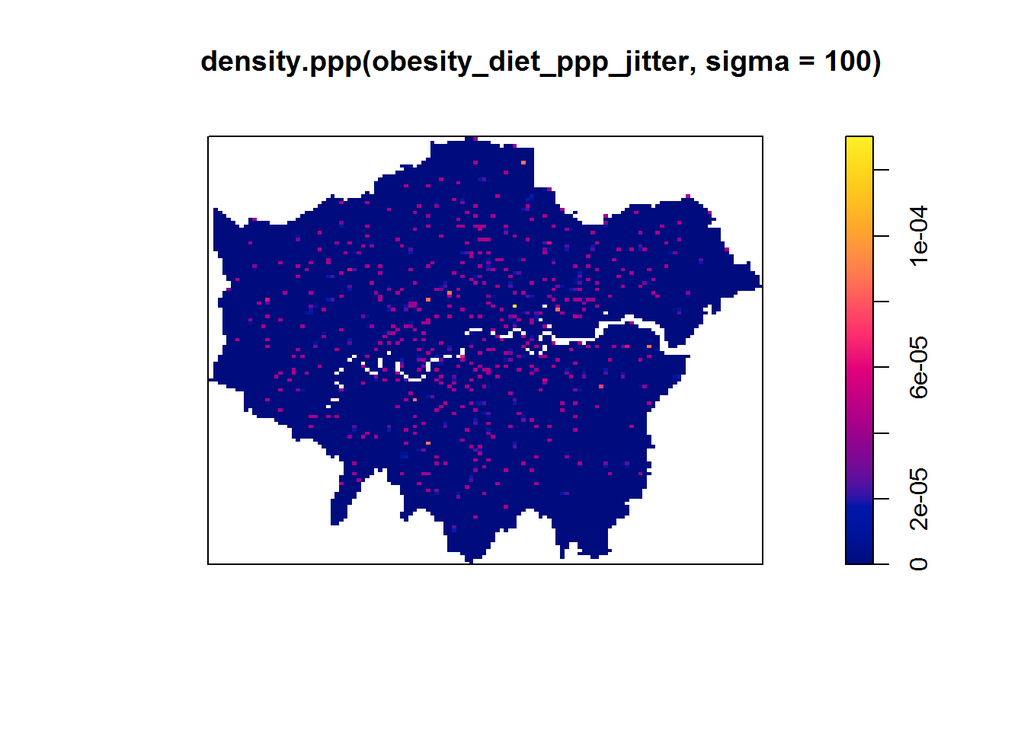

```r
# kernel density estimation with a 100 metre bandwidth
plot(density.ppp(obesity_diet_ppp_jitter,sigma=100))
```

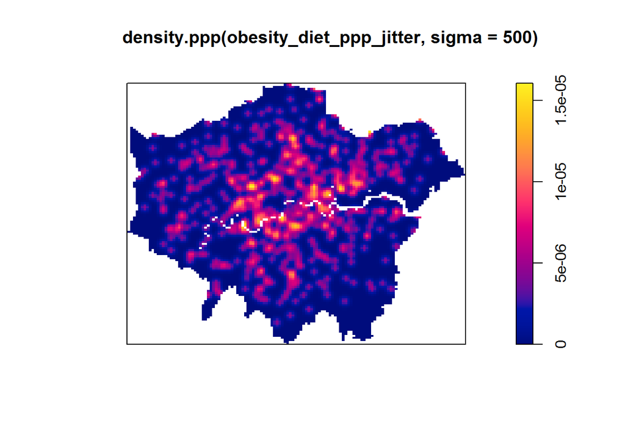

```r
# kernel density estimation with a 500 metre bandwidth
plot(density.ppp(obesity_diet_ppp_jitter,sigma=500))
```

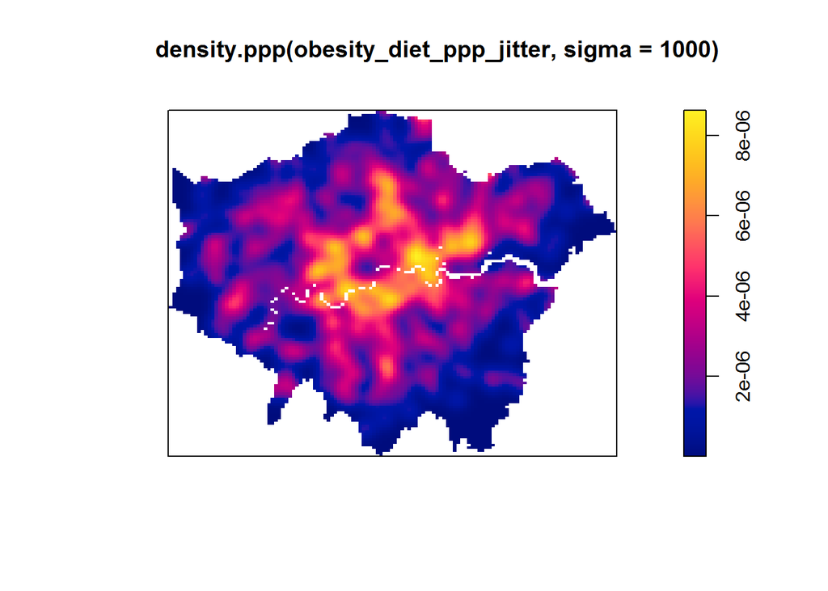

```r
# kernel density estimation with a 1000 metre bandwidth
plot(density.ppp(obesity_diet_ppp_jitter,sigma=1000))
```

bandwidth typically has a more pronounced effect upon the density estimation than the type of kernel used, kernel types can affect the result too. Also here applies: the selection of the kernel depends on how much you want to weigh near points relative to far points (even though this is also influenced by the bandwidth!).

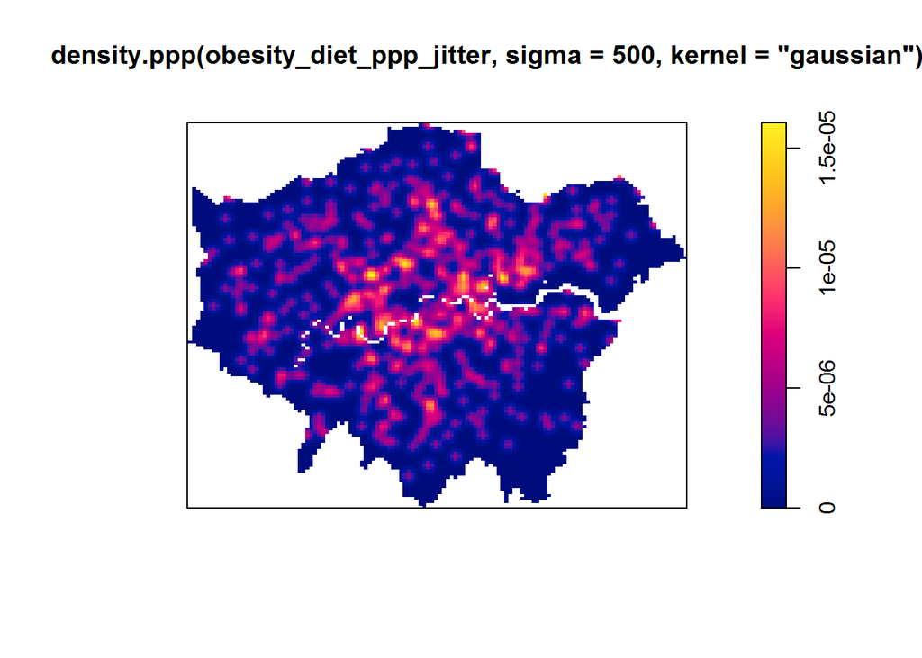

```r
# kernel density estimation with a Gaussian Kernel
plot(density.ppp(obesity_diet_ppp_jitter,sigma=500,kernel='gaussian'))
```

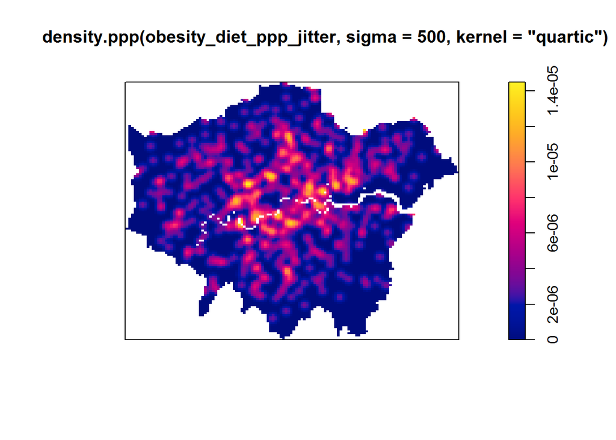

```r
# kernel density estimation with a Quartic Kernel
plot(density.ppp(obesity_diet_ppp_jitter,sigma=500,kernel='quartic'))
```

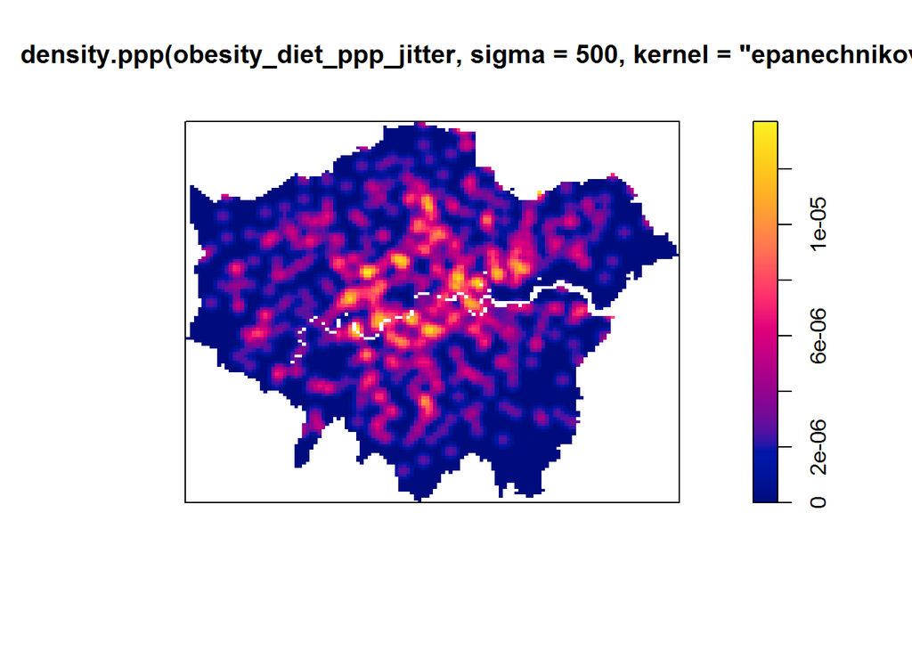

```r
# kernel density estimation with an Epanechnikov Kernel
plot(density.ppp(obesity_diet_ppp_jitter,sigma=500,kernel='epanechnikov'))
```

Bandwidth typically has a more marked effect upon the density estimation than kernel type and is defined as the extent of the area around each grid cell from which the occurrences, and their respective kernels, are drawn.

For now, however, no matter which kernel or which bandwidth (within reason, of course) we use, we can be quite confident in stating that obesity in London is not a spatially random process and we can clearly see the areas where cases is most concentrated.

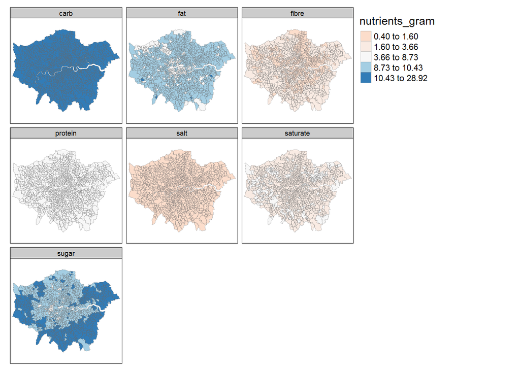

```r
#save.image('plot.RData')
# 3.3 Relationships between obesity and diet
tm_shape(MSOA_obesity_diet_sp_stats) +
 tm_fill("nutrients_gram", palette = "RdBu", style = "quantile", title = "nutrients_gram") +
 tm_facets(by = "nutrients")+
 tm_borders(alpha=.4)
```

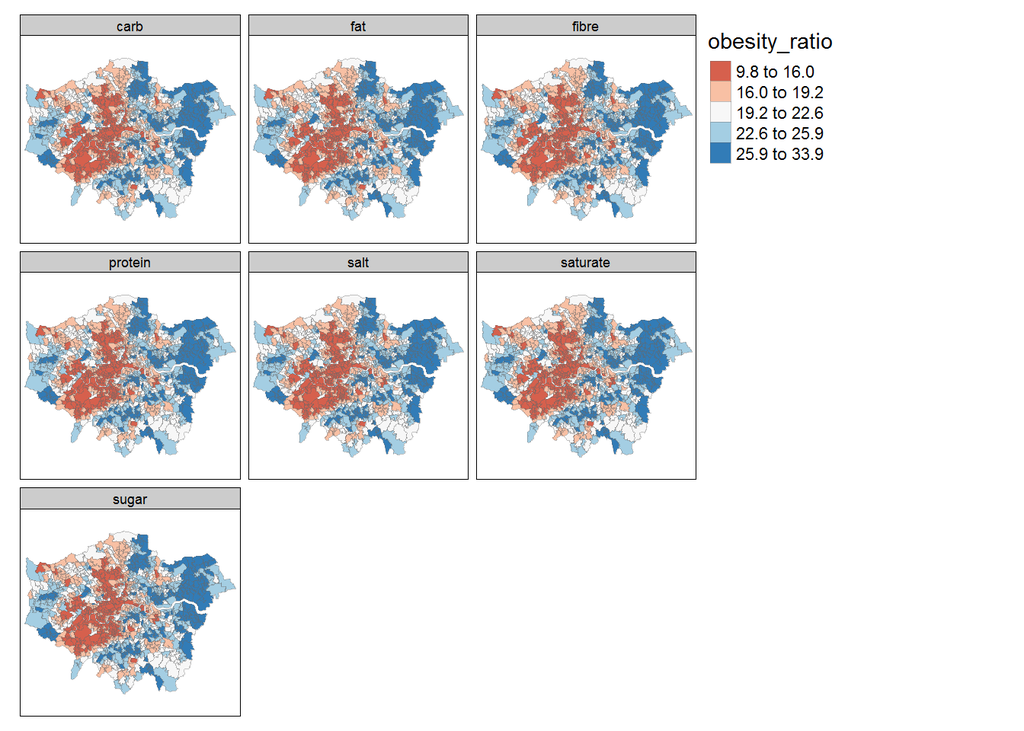

```r
# obesity vs nutrients
tm_shape(MSOA_obesity_diet_sp_stats) +
 tm_fill("obesity_ratio", palette = "RdBu", style = "quantile", title = "obesity_ratio") +
 tm_facets(by = "nutrients")+
 tm_borders(alpha=.4)
```

**NOTE:** We can find that different regions in London show different levels of nutrients_gram and obesity_ratio across different nutrients.

To explore the relationships between obesity and diet, we performs a linear model to predict the obesity of a area.

```r
#merge nutrients and obesity by area_id
msoa_nutrients2 <-merge(obesity_diet2,msoa_data2, by='area_id')
head(msoa_nutrients2)
```

```
##     area_id   weight    volume      fat saturate      salt     sugar  protein
## 1 E02000001 323.1808  98.84923 8.473746 3.361873 0.5304672  9.278385 5.253099
## 2 E02000002 397.6512 118.28842 8.985044 3.454481 0.5613583 10.859950 5.015294
## 3 E02000003 371.2767 118.38562 9.672637 3.872347 0.5304202 12.757477 4.987696
## 4 E02000004 347.4813 104.43541 9.250666 3.532561 0.5806493 11.353290 5.398464
## 5 E02000005 400.5767 128.99744 9.319950 3.673907 0.5780775 11.692790 4.977404
## 6 E02000007 388.1629 118.03442 9.519605 3.643458 0.6028280 11.368979 5.369553
##       carb    fibre   alcohol population male female obesity_ratio
## 1 15.77931 1.619871 0.3407333       6687 3697   2990          13.7
## 2 19.79446 1.615575 0.1807696       7379 3549   3830          29.8
## 3 21.12074 1.602994 0.1875030      10720 5297   5423          28.3
## 4 20.05767 1.618857 0.1519755       6536 3119   3417          26.9
## 5 20.15138 1.603659 0.1412069       9243 4478   4765          29.7
## 6 20.54757 1.544727 0.1739114       9664 4651   5013          29.0
```

```r
# join msoa_nutrients with MSOA of geographic information
MSOA_obesity_diet2 <- merge(MSOA, msoa_nutrients2, by.x='MSOA11CD', by.y='area_id')

# inspect
MSOA_obesity_diet2
```

```
## Simple feature collection with 983 features and 26 fields
## Geometry type: MULTIPOLYGON
## Dimension:     XY
## Bounding box:  xmin: 503574.2 ymin: 155850.8 xmax: 561956.7 ymax: 200933.6
## Projected CRS: OSGB 1936 / British National Grid
## First 10 features:
##     MSOA11CD                 MSOA11NM   LAD11CD              LAD11NM   RGN11CD
## 1  E02000001       City of London 001 E09000001       City of London E12000007
## 2  E02000002 Barking and Dagenham 001 E09000002 Barking and Dagenham E12000007
## 3  E02000003 Barking and Dagenham 002 E09000002 Barking and Dagenham E12000007
## 4  E02000004 Barking and Dagenham 003 E09000002 Barking and Dagenham E12000007
## 5  E02000005 Barking and Dagenham 004 E09000002 Barking and Dagenham E12000007
## 6  E02000007 Barking and Dagenham 006 E09000002 Barking and Dagenham E12000007
## 7  E02000008 Barking and Dagenham 007 E09000002 Barking and Dagenham E12000007
## 8  E02000009 Barking and Dagenham 008 E09000002 Barking and Dagenham E12000007
```

[output cut: 46 more lines]

```r
# runs a linear model
MSOA_obesity_diet_sp2 <- as_Spatial(MSOA_obesity_diet2, IDs=MSOA_obesity_diet$area_id)
model <- lm(obesity_ratio ~  fat+saturate+salt+sugar+protein+carb+fibre, data=MSOA_obesity_diet_sp2)
summary(model)
```

```
##
## Call:
## lm(formula = obesity_ratio ~ fat + saturate + salt + sugar +
##     protein + carb + fibre, data = MSOA_obesity_diet_sp2)
##
## Residuals:
##      Min       1Q   Median       3Q      Max
## -10.1453  -1.6076  -0.0535   1.6638  10.2879
##
## Coefficients:
##             Estimate Std. Error t value Pr(>|t|)
## (Intercept)  31.3575     3.1108  10.080  < 2e-16 ***
## fat           3.8283     0.5644   6.783 2.04e-11 ***
## saturate    -13.0834     1.0400 -12.581  < 2e-16 ***
## salt         28.2004     3.3773   8.350 2.32e-16 ***
## sugar         1.2027     0.1882   6.390 2.57e-10 ***
## protein      -0.8122     0.5567  -1.459    0.145
## carb          1.7156     0.1020  16.811  < 2e-16 ***
## fibre       -33.5569     1.2838 -26.138  < 2e-16 ***
## ---
## Signif. codes:  0 '***' 0.001 '**' 0.01 '*' 0.05 '.' 0.1 ' ' 1
##
## Residual standard error: 2.612 on 975 degrees of freedom
## Multiple R-squared:  0.7457, Adjusted R-squared:  0.7439
## F-statistic: 408.5 on 7 and 975 DF,  p-value: < 2.2e-16
```

There is lots of interesting information we can derive from a linear regression model output. This model has an adjusted R-squared value of 0.7439. So we can assume 74% of the variance can be explained by the model. We can also observe the influences of each of the variables.

# 4 Reading List

## 4.1 List of Reading Materials

- Longley, P. et al. 2015. Geographic Information Science & systems, Chapter 13: Spatial Analysis. [[Link]](https://rl.talis.com/3/ucl/items/fd38ec78-2bea-4165-aab3-0e9d9093db8e.html?lang=en-gb&login=1)
- Lovelace, R., Nowosad, J. and Muenchow, J. 2021. Geocomputation with R, Chapter 4: Spatial data operations. [[Link]](https://geocompr.robinlovelace.net/spatial-operations.html)
- Lovelace, R., Nowosad, J. and Muenchow, J. 2021. Geocomputation with R, Chapter 5: Geometry operations. [[Link]](https://geocompr.robinlovelace.net/geometric-operations.html)
- Gimond, M. 2021. Intro to GIS and spatial analysis. Chapter 13: Spatial autocorrelation. [[Link]](https://mgimond.github.io/Spatial/spatial-autocorrelation.html)
- Cheshire, J. and Longley, P. A. 2011. Identifying spatial concentrations of surnames. International Journal of Geographical Information Science 26(2), pp.309-325. [[Link]](https://doi.org/10.1080/13658816.2011.591291)
- Longley, P. et al. 2015. Geographic Information Science & systems, Chapter 12: Geovisualisation. [[Link]](https://rl.talis.com/3/ucl/items/30C76C0B-1DAD-C865-DEA4-36B33F1EDFD1.html?lang=en-gb&login=1)

## 4.2 Data Sources

The obesity and diet.Download here[[Link]](https://figshare.com/articles/dataset/Area-level_grocery_purchases/7796666?backTo=/collections/Tesco_Grocery_1_0/4769354).

London Statistical GIS boundaries.Download here[[Link]](https://data.london.gov.uk/dataset/statistical-gis-boundary-files-london).

Complete MSOA level obesity data can be found in the MSOA atlas.Download here[[Link]](https://data.london.gov.uk/dataset/msoa-atlas).